# Rによる探索的データ分析入門 - 可視化

## 複数の変数の分布を比較するグラフ

複数の変数の分布を比較するには、色々な方法があります。場合に応じて分かりやすいものを使ってください。

- ヒストグラム  
  指定した区間に含まれるデータの数をプロットしたグラフです。 先ほどの棒グラフと同様に集計処理をRが行います。 Excelだと、あらかじめ集計して度数分布表を作成するが必要がある[^6]ので、ずっと楽に使えます。 区間幅`binwidth`か区間数`bins`を指定してください。

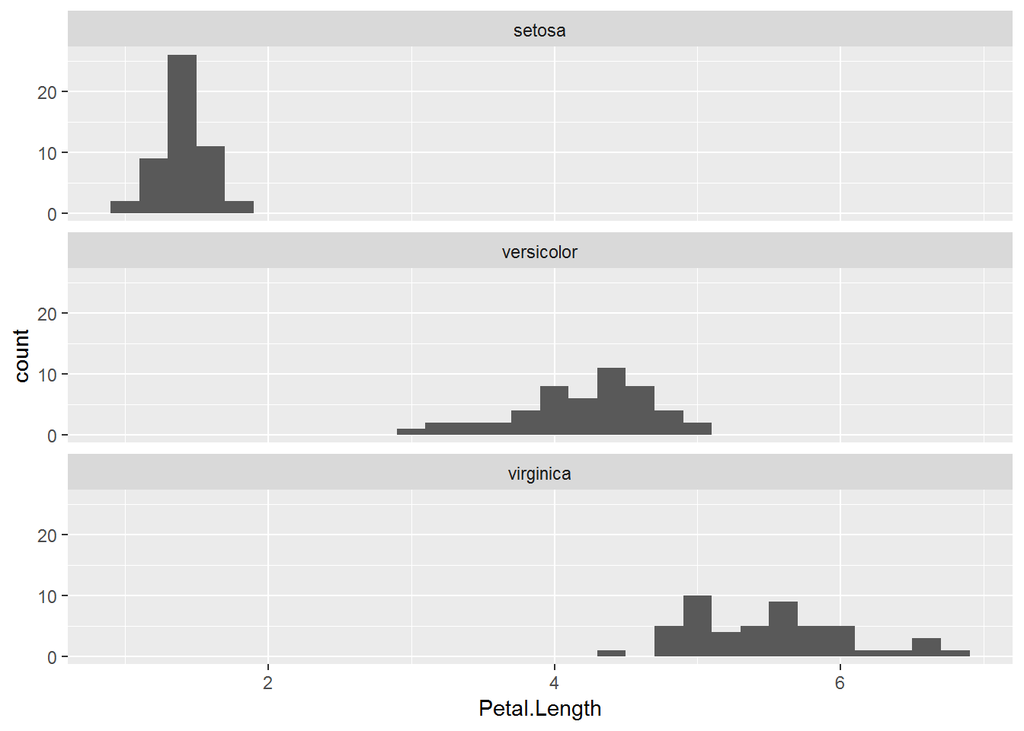

  ヒストグラム

  ```r
  iris %>% ggplot(aes(x = Petal.Length)) +
    geom_histogram(binwidth = 0.2) +
    facet_wrap(~ Species, ncol = 1)
  ```

- 確率密度分布  
  ヒストグラムを平滑化したもので、サブグラフを作らなくても分布を比較しやすいグラフです。

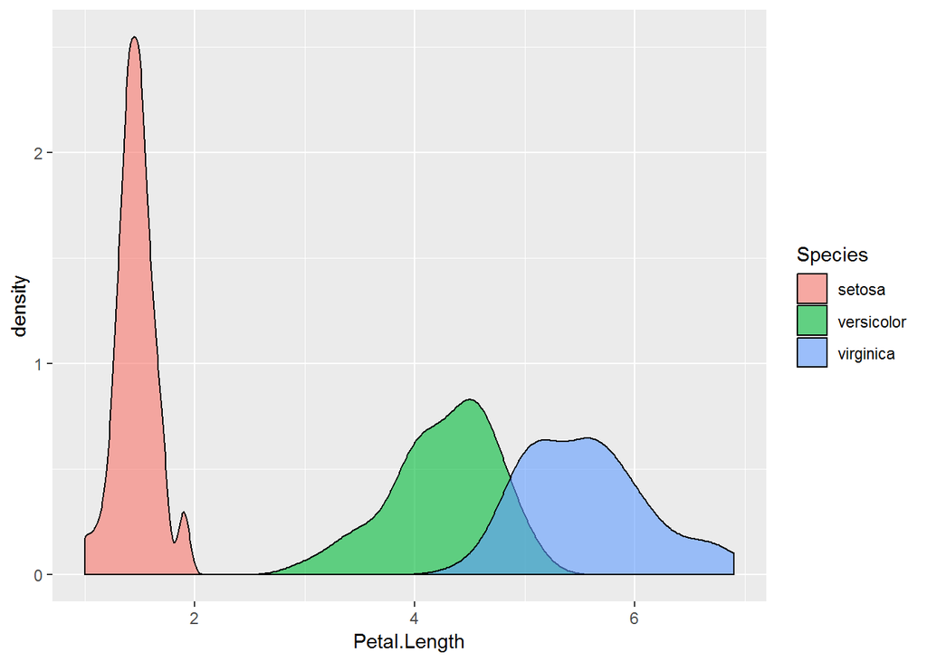

  確率密度分布

  ```r
  iris %>% ggplot(aes(x = Petal.Length, fill = Species)) +
    geom_density(alpha = 0.6)
  ```

- バイオリンプロット  
  確率密度分布を縦に並べたグラフです。 後で説明する箱ひげ図と同様、横軸に連続値の変数を割り当てることもできるので、幅広く使えます。 ここでは、散布図と組み合わせています。

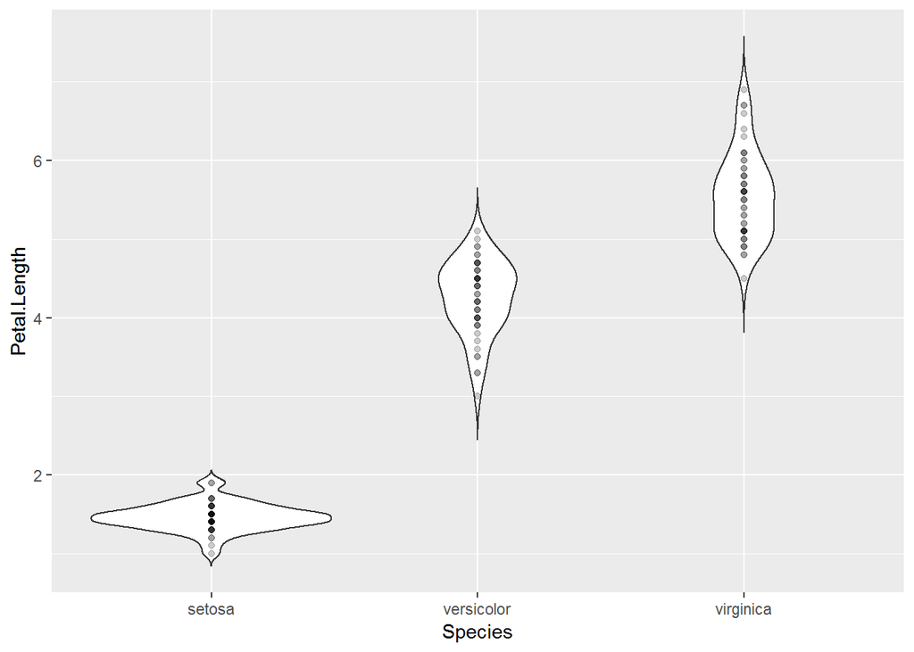

  バイオリンプロット

  ```r
  iris %>% ggplot(aes(x = Species, y = Petal.Length)) +
    geom_violin(trim = F) +
    geom_point(alpha = 0.2)
  ```

- 箱ひげ図  
  四分位点[^7]などを描くグラフで、データ数が少ないときはよく使われます。

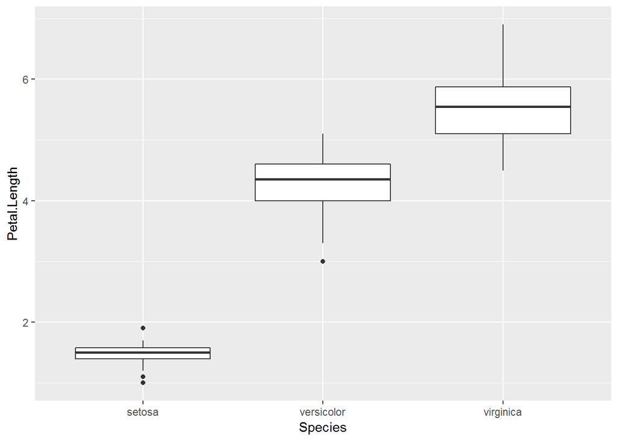

  箱ひげ図

箱ひげ図の意味

| グラフの視覚的属性 | 割り当てられた値 |
| --- | --- |
| 箱の下側の線 | 第1四分位点 |
| 箱の中の線 | 第2四分位点（中央値） |
| 箱の上側の線 | 第3四分位点 |
| 黒丸 | 外れ値[^8] |
| ひげの下端点 | 外れ値を除いた最小値 |
| ひげの上端点 | 外れ値を除いた最大値 |

  ```r
  iris %>% ggplot(aes(x = Species, y = Petal.Length)) + geom_boxplot()
  ```

## 2変数の同時分布を確認するグラフ

2つの変数を組み合わせた分布を可視化する方法を2つ見てみましょう。データは折れ線グラフで使ったものと同じです。

- 2次元ヒストグラム  
  2次元ヒストグラムは、区間内に含まれるデータの個数に応じて色をつけたものです。

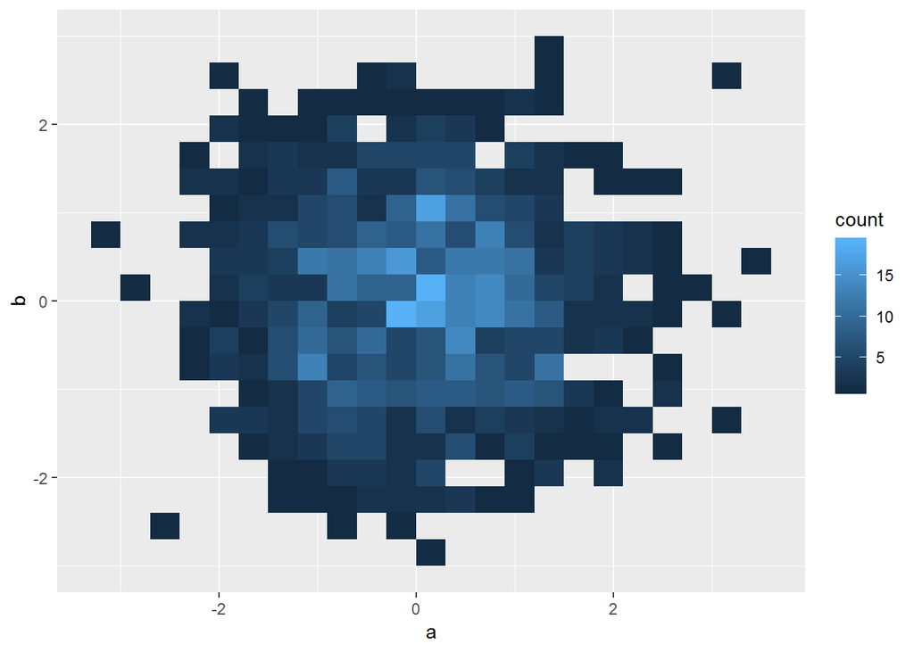

  2次元ヒストグラム

  ```r
  data %>% ggplot(aes(x = a, y = b)) + geom_bin2d(binwidth = 0.3)
  ```

- 2次元確率密度分布  
  2次元確率密度分布は確率密度分布の2次元版（2次元ヒストグラムを平滑化したもの）で、等高線が描かれます。

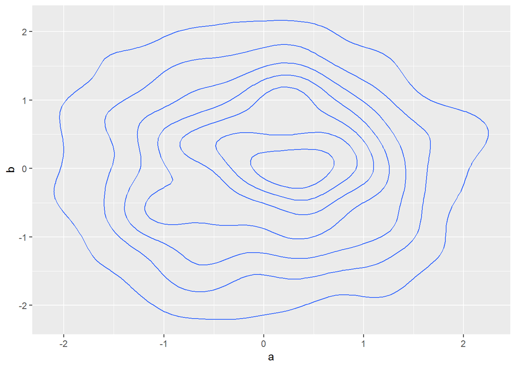

  2次元確率密度分布

  ```r
  data %>% ggplot(aes(x = a, y = b)) + geom_density2d()
  ```

# 様々なグラフ要素

グラフ要素には、下表のように色々な種類があります。 ジオメトリやファセットはすでに紹介したので、その他も簡単に紹介します。 詳細は、メニュー[Help -> Cheetsheets -> Data Visualization with ggplot2]から確認できます。

グラフ要素

| グラフ要素 | 関数名 | 説明 |
| --- | --- | --- |
| ジオメトリ | `geom_*()` | グラフの種類を決める要素 |
| スケール | `scales_*()` | スケールを調整する要素 |
| 座標系 | `coord_*()` | 座標系を指定する要素 |
| ファセット | `facet_*()` | サブグラフを作成する要素 |
| ラベル | `labs()` | ラベルを指定する要素 |
| 凡例 | `guides()` | 凡例を調整する要素 |
| テーマ | `theme_*()` | 全体の見た目を指定する要素 |

- スケール  
  グラフの見た目属性にデータを割り当てるときの尺度（ものさし）を指定します。 例えば、対数軸にしたり軸を反転させたり軸目盛りや目盛りラベルの変更が行なえます。 また、色への割り当てもカラースケールを選ぶことで変更できます。
- 座標系  
  座標系を設定して、X-Yが同比になるように座標系を調整したり、表示する領域を限定したり 極座標にしたりすることができます。
- ラベル  
  グラフの視覚的属性ごとにラベルを指定することができます。
- 凡例  
  グラフの視覚的属性ごとに凡例を調整したり削除したりできます。
- テーマ  
  事前に用意されたテーマから選んで、全体的な見た目を変更できます。 個別に細かい調整を行うことも可能です。

以下に例を示します。

- 例1  
  以下のようにグラフ要素を追加しています。
  - カラースケール：パッケージ`colorRamps`をロードしてMATLABに似た配色を指定する。
  - 座標系 ：X-Yを同比にする。
  - ラベル ：デフォルトの割当てた変数名から変更する。
  - テーマ ：背景が白黒の、プロジェクタで投影するときなどに向いたテーマに変更する。

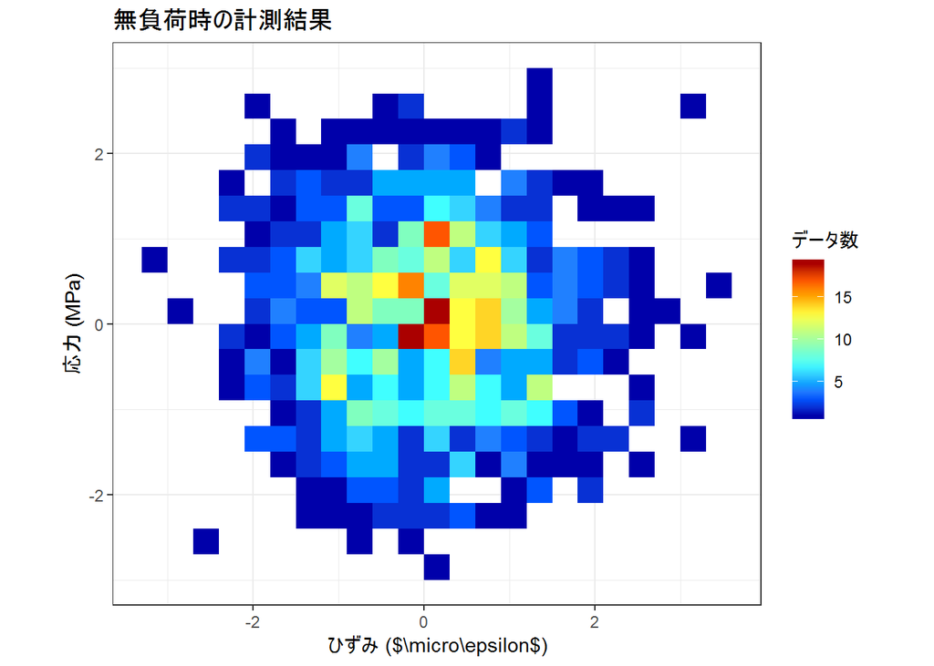

  様々なグラフ要素：例1

  ```r
  library(colorRamps)

  data %>% ggplot(aes(x = a, y = b)) +
    geom_bin2d(binwidth = 0.3) +
    scale_fill_gradientn(colors = matlab.like(10)) +
    coord_fixed() +
    labs(x = "ひずみ ($\\micro\\epsilon$)", y = "応力 (MPa)", fill = "データ数",
         title = "無負荷時の計測結果") +
    theme_bw()
  ```

- 例2  
  以下のようにグラフ要素を追加しています。
  - 座標系 ：メルカトル図法を使う。
  - テーマ ：背景をなくす。

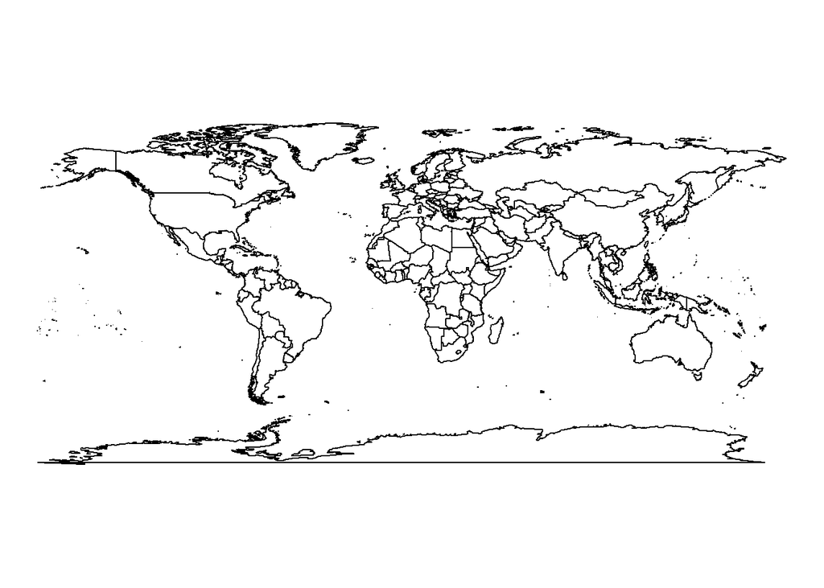

  様々なグラフ要素：例2

  ```r
  library(maps)

  p_map <- map_data("world") %>%
    ggplot(aes(x = long, y = lat, group = group)) +
    geom_polygon(fill = "white", color = "black") +
    theme_void()
  p_map + coord_quickmap()
  ```

- 例3  
  以下のようにグラフ要素を追加しています。
  - 座標系 ：極座標を使う。
  - テーマ ：背景をなくす。

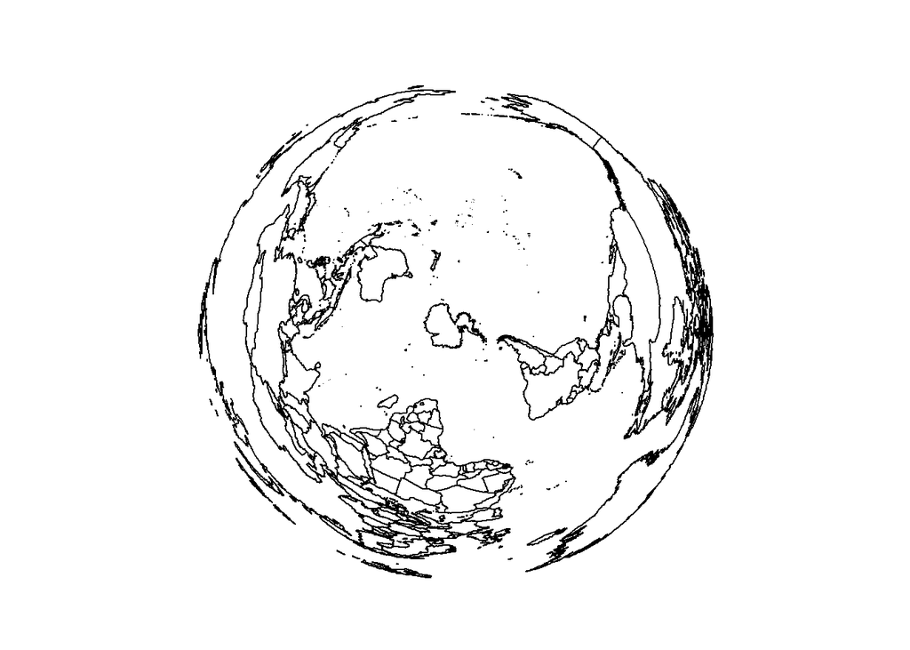

  様々なグラフ要素：例3

  ```r
  p_map + coord_polar()
  ```

[^1]: データ分析をすべてRを使って行うべき、ということではありません。Excelの方がやりやすいこと、計測器に付属する分析ツールや解析ツールのポスト処理を使う方が効率的なことも、もちろんあります。Rを使った方が有効なときに使ってください。その判断は、これから勉強していくうちにできるようになります。
[^2]: より正確にはtidyverseパッケージにというべきですが、それについては後日お話します。
[^3]: 生態学のデータで、アヤメの花弁（petal）とガク（sepal）の長さと幅を、3つの種について50個体ずつ計測したもの。
[^4]: これはよくない例だということを覚えておいてください。また、ここでは更に点のマーカーの形への割当も追加していますが、`"Sepal"`や`"Petal"`という値を持った名前のない変数を割り当てた、と考えることができます。少し特殊な例なので無視して構いません。
[^5]: `tibble()`はテーブルデータを作る処理、`rnorm()`は正規分布に従う乱数を指定された個数作る処理です。 詳細は後で勉強します。
[^6]: アドオンの分析ツールを使う方法もありますが、階級の境界値をすべて入力する必要があり、手間は変わりません。
[^7]: データを値の順に並べたとき全体の個数の25%、50%、75%の位置にある値のこと。 個別には、第1四分位点、第2四分位点（中央値）、第3四分位点と呼ばれる。
[^8]: 箱の両側から箱の幅の1.5倍より離れたデータを外れ値とするのがデフォルト。